# Practical Machine Learning to predict the performance of exercise based on Persobnal Device data. Report

Sam Kanta

2023-12-02

## Introduction

The quantified self movement has made it possible to collect a large amount of data about personal activity relatively inexpensively, using devices such as Jawbone Up, Nike FuelBand, and Fitbit. Enthusiasts who take measurements about themselves regularly to improve their health, to find patterns in their behavior, or simply because they are tech geeks are part of this group. People often quantify how much of a particular activity they do, but they rarely quantify how well they do it.

In this project, the goal was to use data from accelerometers on the belt, forearm, arm, and dumbell of 6 participants - each asked to perform barbell lifts correctly and incorrectly in 5 different ways. Applying a machine learning algorithm, with techniques improving quality of model fit, we will predict the *manner* in which the 6 participants did the exercise. The following sections summarize the approach for this project.

## Preparing the Data

Before any model develop occured, the corresponding R libraries were enabled and the source files for the data downloaded.

```r
library(e1071)
library(caret)
library(rpart)
library(rpart.plot)
library(randomForest)
library(corrplot)
```

```r
trainUrl <-"https://d396qusza40orc.cloudfront.net/predmachlearn/pml-training.csv"
testUrl <- "https://d396qusza40orc.cloudfront.net/predmachlearn/pml-testing.csv"
trainFile <- "./data/pml-training.csv"
testFile  <- "./data/pml-testing.csv"
if (!file.exists("./data")) {
  dir.create("./data")
}
if (!file.exists(trainFile)) {
  download.file(trainUrl, destfile=trainFile, method="curl")
}
if (!file.exists(testFile)) {
  download.file(testUrl, destfile=testFile, method="curl")
}
```

### Reading the Data

After downloading the data, the csv files were transformed into two data frames.

```r
trainRaw <- read.csv("./data/pml-training.csv")
testRaw <- read.csv("./data/pml-testing.csv")
dim(trainRaw)
```

```
## [1] 19622   160
```

```r
dim(testRaw)
```

```
## [1]  20 160
```

The training data set contains 19,622 observations and 160 variables, while the testing data set contains 20 observations and 160 variables. The “classe” variable in the training set is the outcome to predict.

### Cleaning the Data

Before creating the predictor model, the data needs to be cleaned to remove potential outliers that would otherwise reduce the accuracy of the algorithm. This was done in three parts:

1. Identify complete cases

```r
sum(complete.cases(trainRaw))
```

```
## [1] 406
```

2. Remove columns that contain NA missing values.

```r
trainRaw <- trainRaw[, colSums(is.na(trainRaw)) == 0]
testRaw <- testRaw[, colSums(is.na(testRaw)) == 0]
```

3. Remove columns that do not contribute to performance measurements.

```r
classe <- trainRaw$classe
trainRemove <- grepl("^X|timestamp|window", names(trainRaw))
trainRaw <- trainRaw[, !trainRemove]
trainCleaned <- trainRaw[, sapply(trainRaw, is.numeric)]
trainCleaned$classe <- classe
testRemove <- grepl("^X|timestamp|window", names(testRaw))
testRaw <- testRaw[, !testRemove]
testCleaned <- testRaw[, sapply(testRaw, is.numeric)]
```

The resulting training data set contains 19,622 observations and 53 variables, while the testing data set contains 20 observations and 53 variables. Note that the *classe* variable remains in the cleaned training set.

### Slicing the Data

The cleaned training set is split into a pure training data set (70%) and a validation data set (30%). The validation data set assists in conducting cross validation.

```r
set.seed(22519) # For reproducibile purpose
inTrain <- createDataPartition(trainCleaned$classe, p=0.70, list=F)
trainData <- trainCleaned[inTrain, ]
testData <- trainCleaned[-inTrain, ]
```

## Modeling a Predictive Algoritm for the Data

We fit a predictive model for activity recognition using a **Random Forest** algorithm because it automatically selects key variables and is robust to correlated covariates & outliers. The **5-fold cross validation** is used when applying the algorithm.

```r
controlRf <- trainControl(method="cv", 5)
modelRf <- train(classe ~ ., data=trainData, method="rf", trControl=controlRf, ntree=250)
modelRf
```

```
## Random Forest
##
## 13737 samples
##    52 predictor
##     5 classes: 'A', 'B', 'C', 'D', 'E'
##
## No pre-processing
## Resampling: Cross-Validated (5 fold)
## Summary of sample sizes: 10988, 10989, 10989, 10991, 10991
## Resampling results across tuning parameters:
##
##   mtry  Accuracy   Kappa
##    2    0.9903191  0.9877528
##   27    0.9919204  0.9897794
##   52    0.9840581  0.9798338
##
## Accuracy was used to select the optimal model using the largest value.
## The final value used for the model was mtry = 27.
```

The performance of the model is estimated from the validation data set.

```r
#Predicting
predictRf <- predict(modelRf, newdata = testData)
#Testing accuracy
confusionMatrix(table(predictRf, testData$classe))
```

```
## Confusion Matrix and Statistics
##
##
## predictRf    A    B    C    D    E
##         A 1669    5    0    0    0
##         B    2 1130    4    0    0
##         C    3    3 1019   10    4
##         D    0    1    3  954    2
##         E    0    0    0    0 1076
##
## Overall Statistics
##
##                Accuracy : 0.9937
##                  95% CI : (0.9913, 0.9956)
##     No Information Rate : 0.2845
##     P-Value [Acc > NIR] : < 2.2e-16
##
##                   Kappa : 0.992
##
##  Mcnemar's Test P-Value : NA
##
## Statistics by Class:
##
##                      Class: A Class: B Class: C Class: D Class: E
## Sensitivity            0.9970   0.9921   0.9932   0.9896   0.9945
## Specificity            0.9988   0.9987   0.9959   0.9988   1.0000
## Pos Pred Value         0.9970   0.9947   0.9808   0.9937   1.0000
## Neg Pred Value         0.9988   0.9981   0.9986   0.9980   0.9988
## Prevalence             0.2845   0.1935   0.1743   0.1638   0.1839
## Detection Rate         0.2836   0.1920   0.1732   0.1621   0.1828
## Detection Prevalence   0.2845   0.1930   0.1766   0.1631   0.1828
## Balanced Accuracy      0.9979   0.9954   0.9945   0.9942   0.9972
```

```r
accuracy <- postResample(table(predictRf), table(testData$classe))
accuracy
```

```
##      RMSE  Rsquared       MAE
## 6.7823300 0.9992941 5.2000000
```

```r
oose <- 1 - as.numeric(confusionMatrix(table(testData$classe, predictRf))$overall[1])
oose
```

```
## [1] 0.006287171
```

### Final Data Model with the Top Twenty Predictor Variables

```r
modelRf$finalModel
```

```
##
## Call:
##  randomForest(x = x, y = y, ntree = 250, mtry = param$mtry)
##                Type of random forest: classification
##                      Number of trees: 250
## No. of variables tried at each split: 27
##
##         OOB estimate of  error rate: 0.69%
## Confusion matrix:
##      A    B    C    D    E class.error
## A 3900    5    1    0    0 0.001536098
## B   23 2628    6    1    0 0.011286682
## C    0    8 2378   10    0 0.007512521
## D    0    1   20 2227    4 0.011101243
## E    0    3    3   10 2509 0.006336634
```

```r
varImp(modelRf)
```

```
## rf variable importance
##
##   only 20 most important variables shown (out of 52)
##
##                      Overall
## roll_belt            100.000
## pitch_forearm         60.497
## yaw_belt              52.479
## pitch_belt            42.770
## magnet_dumbbell_z     42.175
## roll_forearm          41.435
## magnet_dumbbell_y     40.922
## accel_dumbbell_y      19.075
## roll_dumbbell         18.299
## magnet_dumbbell_x     17.540
## accel_forearm_x       17.333
## accel_belt_z          15.212
## magnet_belt_z         14.879
## accel_dumbbell_z      13.713
## total_accel_dumbbell  13.536
## magnet_forearm_z      13.476
## magnet_belt_y         11.927
## gyros_belt_z          10.721
## yaw_arm               10.588
## magnet_belt_x          9.371
```

## Appendix: Figures - Data Visualization

### 1. Correlation Matrix Visualization

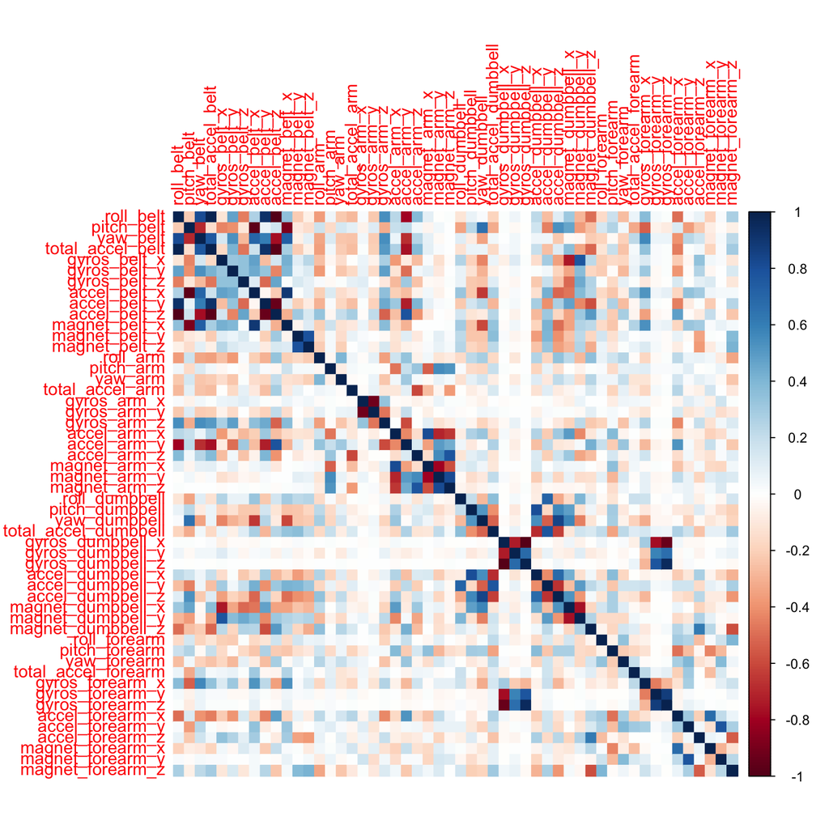

```r
corrPlot <- cor(trainData[, -length(names(trainData))])
corrplot(corrPlot, method="color")
```

### 2. Decision Tree Visualization

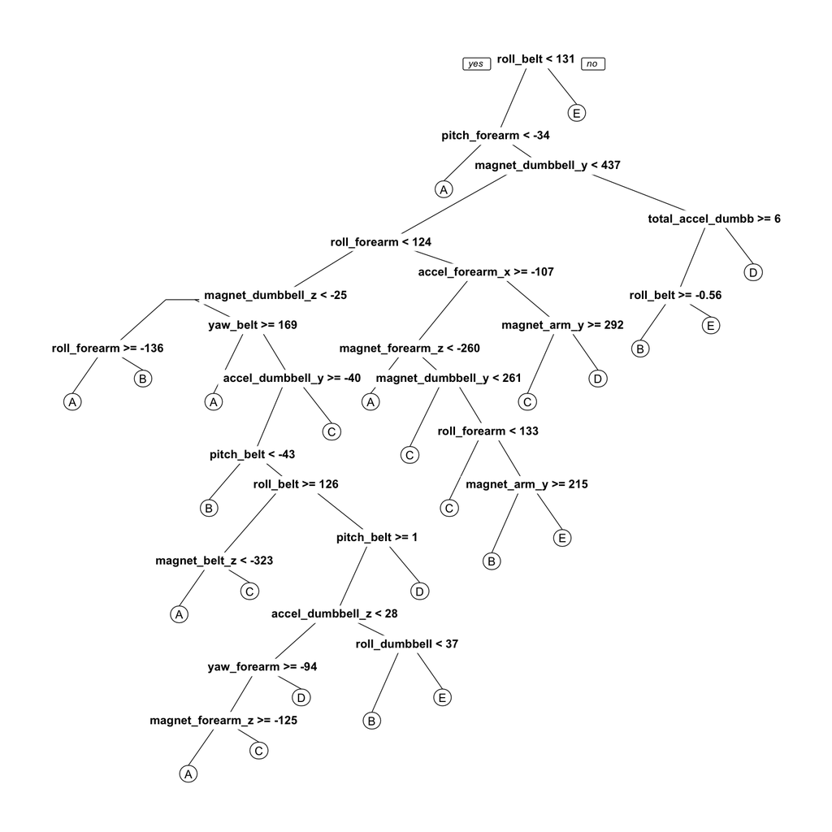

```r
treeModel <- rpart(classe ~ ., data=trainData, method="class")
prp(treeModel) # fast plot
```

## Predicting for Test Data Set (for Course Project Prediction Quiz Portion)

The prediction model was applied to the original testing data set, downloaded from the data source.

```r
result <- predict(modelRf, testCleaned[, -length(names(testCleaned))])
result
```

```
##  [1] B A B A A E D B A A B C B A E E A B B B
## Levels: A B C D E
```